Microscopic organisms with a massive impact, phytoplankton provide nearly half of the earth’s atmospheric oxygen and consume carbon dioxide on a scale equivalent to forests. At the foundation of aquatic food webs, they are critical to the health of the ocean. Toxic phytoplankton have an impact on public health and commercial fisheries.

Highly anomalous ocean conditions fueled a widespread bloom of phytoplankton, including toxin-producing pennate diatoms. These toxins moved through the foodweb with various impacts, including stranded marine mammals and the longest closure of the west coast Dungeness crab fishery.

[interactive chart not shown]

In 2015 pennate diatom levels were elevated and there was a wide-spread bloom of domoic acid-producing pennate diatoms, an event also know as harmful algal bloom or HAB. https://sanctuarysimon.org/monterey-bay-nms/harmful-algal-blooms/

[interactive chart not shown]

Centric diatoms are often thought of as signature or “keystone” phytoplankton species within upwelling systems. They are important for supplying an estimated 45% of total primary production of organic material to the ocean’s food web.

[interactive chart not shown]

In 2004, dinoflagellates replaced diatoms as the dominant phytoplankton taxon in Monterey Bay. This shift in “keystone” phytoplankon is associated with an increase in near surface stratification and a decrease in upwelling-favorable winds. Some species of dinoflagellates are known to produce toxic phytoplankton blooms known as “red tide”.

[interactive chart not shown]

During spring upwelling, centric diatoms dominate under high nutrients and external energy input. As upwelling weakens in late summer and nutrients decrease, pennate diatoms become prevalent. In the fall, dinoflagellates are more abundant in stratified waters where turbulence is weak. Under unusual conditions of high nutrient availability and strong stratification toxic red tides can develop.

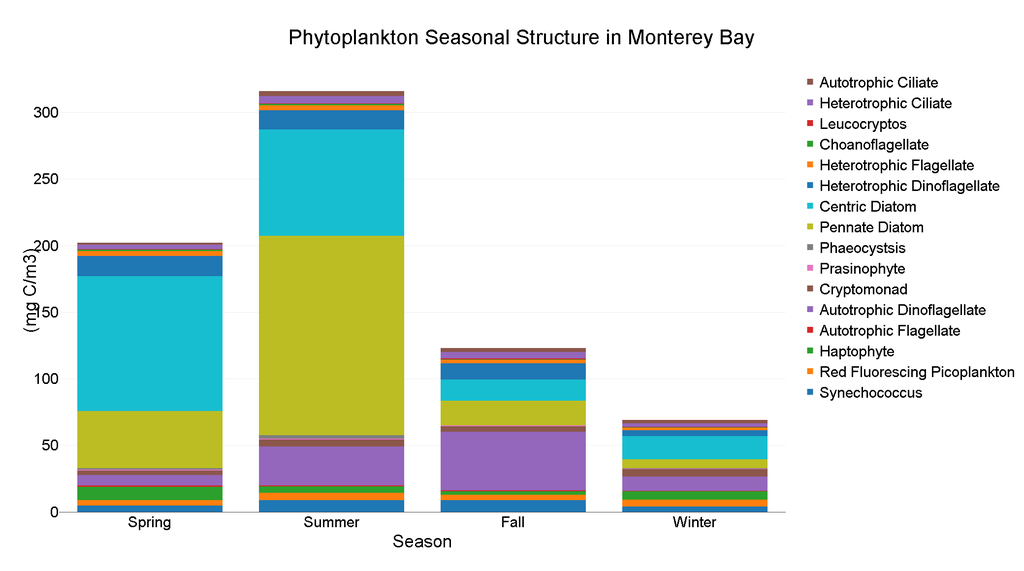

The phytoplankton time series is from Monterey Bay Station M1, 36.75N, -122.02W. Phytoplankton counts using an epifluorescent microscope, a compound microscope equipped with a high-intensity light source which emits light in a broad spectrum from visible through ultraviolet. Units have been converted to mg Carbon/m3. MBARI provides data “as is”, with no warranty, express or implied, of the quality or consistency. Data are provided without support and without obligation on the part of the Monterey Bay Aquarium Research Institute to assist in its use, correction, modification, or enhancement. Monterey Bay Aquarium Research Institute (MBARI) Biological Oceanography Group, Francisco Chavez. http://www.mbari.org